# Correcciones radiométricas

(a) Realice la calibración radiométrica de las bandas ópticas que conforman su imagen de trabajo (incluya las regiones VIS, NIR, SWIR y TIR).

```r
#Loading libraries
library(ggplot2)
library(reshape2)
library(xml2)
library(rjson)
library(lubridate)
library(RStoolbox)
library(raster)
library(repr)

setwd("/Users/oscar/Code/Maestria/perc_remota/data/")
```

Cargando imagen de trabajo

```r
#Loading image
image_id='20171220_143931_1024'
bands <- c("Blue","Green","Red","NIR")

image_route <- sprintf("images/%s/%s_3B_AnalyticMS.tif",image_id,image_id)
image <-  stack(image_route)
names(image) <- bands
```

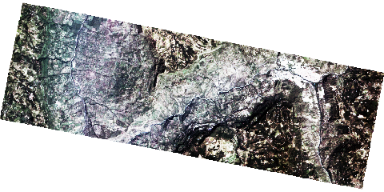

```r
options(repr.plot.width=4, repr.plot.height=2)
plotRGB(image,r=3,g=2,b=1, stretch = "hist")
```

Se crea la función que extrae la información desde los archivos de metadatos de la imágen. La imagen usada únicamente tiene un valor multiplicativo llamado radiometricScaleFactor más no un factor aditivo.Se cargan los valores multiplicativos dentro de los metadatos de la imagen.

```r
#Loading Radiometric scale factors
image_metadata_route = sprintf("images/%s/%s_3B_AnalyticMS_metadata.xml",image_id,image_id)
image_metadata <- read_xml(image_metadata_route)
radiometric_scale_factors <- xml_double(xml_find_all(image_metadata, "//ps:radiometricScaleFactor"))
names(radiometric_scale_factors) <- bands
image_json_route = sprintf("images/%s/%s_metadata.json",image_id,image_id)
json_data <- fromJSON(paste(readLines(image_json_route), collapse=""))
#Loading image
image_route <- sprintf("images/%s/%s_3B_AnalyticMS.tif",image_id,image_id)
image <-  stack(image_route)
names(image) <- bands
```

## Cálculo de radiancia espectral

Se Calcula la radiancia espectral para cada banda de la imágen.

```r
#Calculating  spectral radiance for each band in the image
lsx <- image
for(band in bands) {
  lsx[[band]] <- radiometric_scale_factors[band] * image[[band]]
}

for(band in bands) {
  print(lsx[[band]])
}
```

```
class       : RasterLayer
dimensions  : 4352, 8985, 39102720  (nrow, ncol, ncell)
resolution  : 3, 3  (x, y)
extent      : 684891, 711846, 717039, 730095  (xmin, xmax, ymin, ymax)
coord. ref. : +proj=utm +zone=18 +datum=WGS84 +units=m +no_defs +ellps=WGS84 +towgs84=0,0,0
data source : in memory
names       : Blue
values      : 17.01, 292.49  (min, max)

class       : RasterLayer
dimensions  : 4352, 8985, 39102720  (nrow, ncol, ncell)
resolution  : 3, 3  (x, y)
extent      : 684891, 711846, 717039, 730095  (xmin, xmax, ymin, ymax)
coord. ref. : +proj=utm +zone=18 +datum=WGS84 +units=m +no_defs +ellps=WGS84 +towgs84=0,0,0
data source : in memory
names       : Green
values      : 23.5, 220.07  (min, max)

class       : RasterLayer
dimensions  : 4352, 8985, 39102720  (nrow, ncol, ncell)
resolution  : 3, 3  (x, y)
extent      : 684891, 711846, 717039, 730095  (xmin, xmax, ymin, ymax)
coord. ref. : +proj=utm +zone=18 +datum=WGS84 +units=m +no_defs +ellps=WGS84 +towgs84=0,0,0
data source : in memory
names       : Red
values      : 5.02, 272.05  (min, max)

class       : RasterLayer
dimensions  : 4352, 8985, 39102720  (nrow, ncol, ncell)
resolution  : 3, 3  (x, y)
extent      : 684891, 711846, 717039, 730095  (xmin, xmax, ymin, ymax)
coord. ref. : +proj=utm +zone=18 +datum=WGS84 +units=m +no_defs +ellps=WGS84 +towgs84=0,0,0
data source : in memory
names       : NIR
values      : 14.86, 274.1  (min, max)
```

(b) Calcule la reflectancia DOS y COST de las bandas VIS, NIR y SWIR.

- Para calcular las Reflectancias se deben encontrar los valores de ganancia (G) y sesgo (B) para convertir ND de cada banda en radiancia espectral. Se toman los valores de radiancia espectral calculados en el punto anterior.

## Cálculo de reflectancia TOA.

Se cargan los de coeficientes de reflectancia en los metadatos de la imágen reflectanceCoefficient. No se divide por el coseno del ángulo zenital solar ya que los valores de reflectancia son mayores de uno al hacer esa operación.

```r
reflectance_coefficient <- xml_double(xml_find_all(image_metadata, "//ps:reflectanceCoefficient"))
names(reflectance_coefficient) <- bands

reflectance_coefficient
```

**Blue**

2.17339025761e-05

**Green**

2.29824335517e-05

**Red**

2.56527294581e-05

**NIR**

3.860358776e-05

```r
ac_toa <- image

for(band in bands) {
  ac_toa[[band]] <- (reflectance_coefficient[band] * image[[band]])
}
for(band in bands) {
  print(ac_toa[[band]])
}
```

```
class       : RasterLayer
dimensions  : 4352, 8985, 39102720  (nrow, ncol, ncell)
resolution  : 3, 3  (x, y)
extent      : 684891, 711846, 717039, 730095  (xmin, xmax, ymin, ymax)
coord. ref. : +proj=utm +zone=18 +datum=WGS84 +units=m +no_defs +ellps=WGS84 +towgs84=0,0,0
data source : in memory
names       : Blue
values      : 0.03696937, 0.6356949  (min, max)

class       : RasterLayer
dimensions  : 4352, 8985, 39102720  (nrow, ncol, ncell)
resolution  : 3, 3  (x, y)
extent      : 684891, 711846, 717039, 730095  (xmin, xmax, ymin, ymax)
coord. ref. : +proj=utm +zone=18 +datum=WGS84 +units=m +no_defs +ellps=WGS84 +towgs84=0,0,0
data source : in memory
names       : Green
values      : 0.05400872, 0.5057744  (min, max)

class       : RasterLayer
dimensions  : 4352, 8985, 39102720  (nrow, ncol, ncell)
resolution  : 3, 3  (x, y)
extent      : 684891, 711846, 717039, 730095  (xmin, xmax, ymin, ymax)
coord. ref. : +proj=utm +zone=18 +datum=WGS84 +units=m +no_defs +ellps=WGS84 +towgs84=0,0,0
data source : in memory
names       : Red
values      : 0.01287767, 0.6978825  (min, max)

class       : RasterLayer
dimensions  : 4352, 8985, 39102720  (nrow, ncol, ncell)
resolution  : 3, 3  (x, y)
extent      : 684891, 711846, 717039, 730095  (xmin, xmax, ymin, ymax)
coord. ref. : +proj=utm +zone=18 +datum=WGS84 +units=m +no_defs +ellps=WGS84 +towgs84=0,0,0
data source : in memory
names       : NIR
values      : 0.05736493, 1.058124  (min, max)
```

```
Blue Band TOA ReflectanceGreen Band TOA ReflectanceRed Band TOA ReflectanceNIR Band TOA Reflectance
```

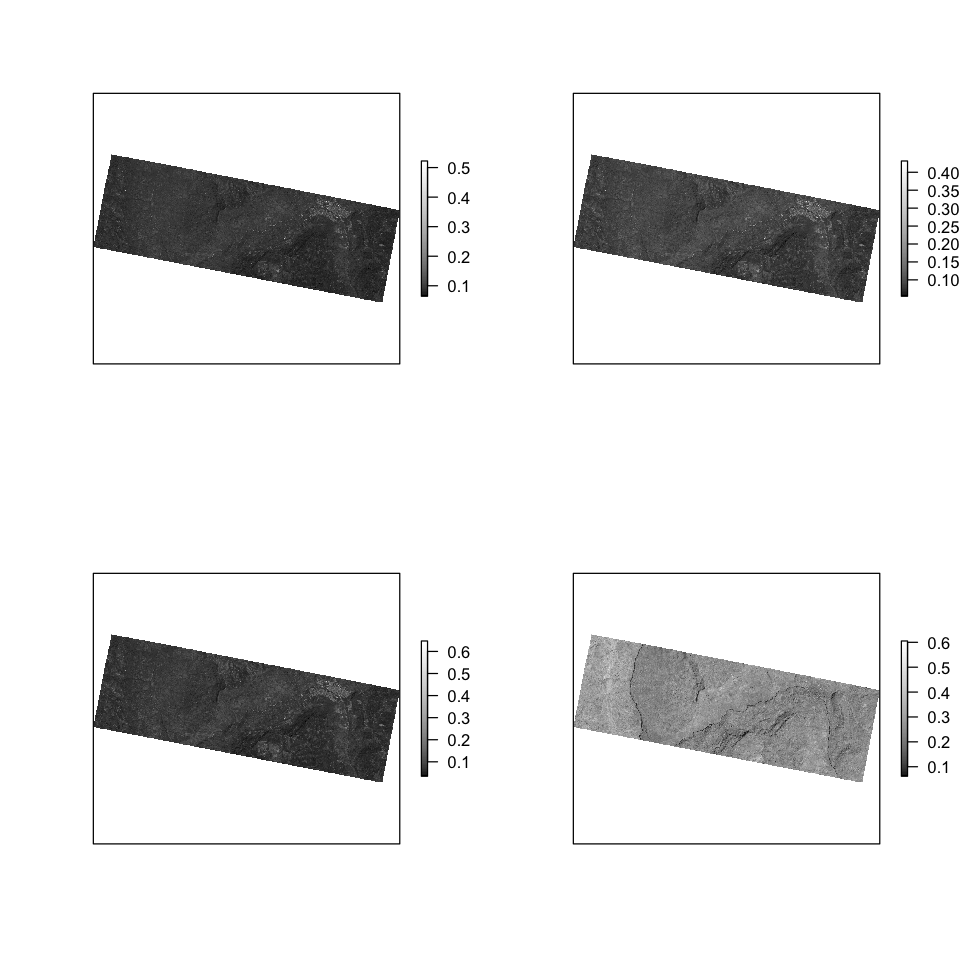

```r
grayscale_colors <- gray.colors(100,            # number of different color levels
start = 0.0,    # how black (0) to go
end = 1.0,      # how white (1) to go
gamma = 2.2,    # correction between how a digital
# camera sees the world and how human eyes see it
alpha = NULL)   #Null=colors are notT transparent
options(repr.plot.width=8, repr.plot.height=8)
par(mfrow=c(2,2))

for(band in bands) {
  plot(ac_toa[[band]],
     col=grayscale_colors,
     axes=FALSE,
     main=cat(band, " Band TOA Reflectance", sep="")
    )
}
```

## Cálculo de reflectancia DOS

Para el cálculo de de la reflectancia DOS es necesario calcular los valores ESUN (Irradiancia Solar).También se necesita el ángulo Zenital Solar.

```r
#Solar Zenith Angle
theta <- 90 -json_data$properties$sun_elevation
```

Se cargan los valores del espectro de irradiancia solar.

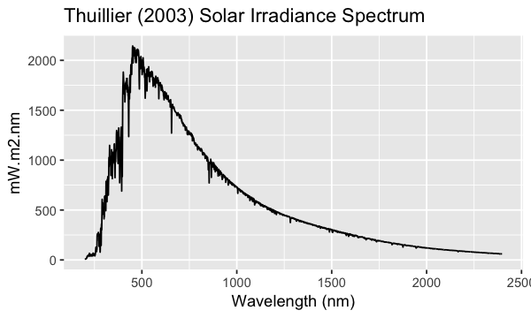

```r
solar_irradiance <- read.csv(file="solar_irradiance.csv", header=TRUE, sep=",")
options(repr.plot.width=5, repr.plot.height=3)

ggplot(solar_irradiance, aes(x = nm, y = mW.m2.nm)) + geom_line() + ggtitle("Thuillier (2003) Solar Irradiance Spectrum") + xlab("Wavelength (nm)")
```

Se importan los valores e la respuesta especral relativa del sensor

```r
rsr <- read.csv(file="rsr.csv", header=TRUE, sep=",")
rsr$wl <- rsr$wl * 1000
resp <- lapply(seq(2,ncol(rsr)), function(x){
  tmp <- rsr[,c(1,(x))]
  names(tmp) <- c("Wavelength","BA.RSR..watts.")
  data.frame(tmp)
})
names(resp) <- bands
```

Se interpolan los datos para que esten en el mismo rango

```r
## Linearly interpolate solar irradiance spectrum even finer
sora <- range(solar_irradiance[,1])
xnew <- seq(sora[1],sora[2], 0.01)
ynew <- resamp  <- approx(x = solar_irradiance[,1], y = solar_irradiance[,2], xout = xnew)[["y"]]
solar_irradiance  <- cbind(xnew,ynew)
```

Se grafica la respuesta espectral del sensor Planetscope

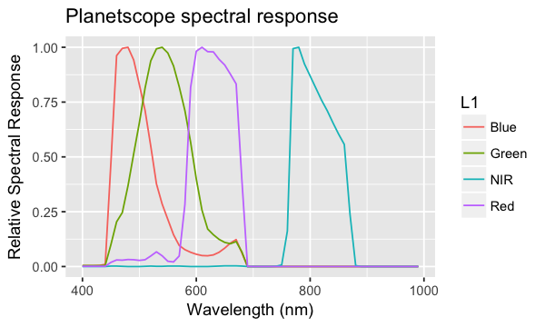

```r
## Plot
respDf <- melt(resp, c("Wavelength", "BA.RSR..watts."))
ggplot(respDf, aes( x = Wavelength, y = BA.RSR..watts., colour = L1)) +
  geom_line() + ggtitle("Planetscope spectral response")+
  xlab("Wavelength (nm)")+
  ylab("Relative Spectral Response")
```

Se calculan los valores de Esun para cada Banda

```r
Esun <- sapply(resp, function(x){
  ## Resample band response to solar spectrum
  resamp  <- approx(x = x[,1], y = x[,2], xout = solar_irradiance[,1])[["y"]]
  ## Convert to relative weights
  weights <- resamp / sum(resamp, na.rm = TRUE)
  ## Calculated weighted sum
  sum(solar_irradiance[,2] * weights, na.rm = TRUE)
})
round(Esun,2)
```

**Blue**

1932.19

**Green**

1836.45

**Red**

1644.93

**NIR**

1099.93

Es necesario calcular la distancia tierra-sol d. S importa la base de datos de la librería RSToolbox que tiene esos datos dependiendo del día del año.

```r
image_acquisition_date <- xml_text(xml_find_all(image_metadata, "//ps:acquisitionDateTime"))
image_yday <- yday(as.Date(image_acquisition_date))
.ESdistance <- readRDS("sun_earth_dists.rds")
d <- .ESdistance[image_yday]
d
```

0.983878054288794

Se buscan los valores más oscuros de reflectancia en la imágen

**Blue**

31

**Green**

26

**Red**

16

**NIR**

18

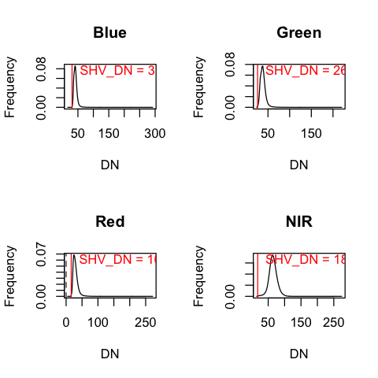

```r
haze <- estimateHaze(lsx, hazeBands = 1:nlayers(image), plot = TRUE)
haze
```

Calculando LPATH. El cuál está definido por la diferencia entre la reflectancia del objeto más oscuro y el 1%

```r
haze
angle <- cos(theta*pi/180)
Ldo <- (0.01 * (Esun * angle)) / (pi * d ^ 2)
Ldo
Lpath <- haze - Ldo
Lpath
```

**Blue**

31

**Green**

26

**Red**

16

**NIR**

18

**Blue**

4.58575972274983

**Green**

4.35852915427675

**Red**

3.90398840005205

**NIR**

2.61052286577316

**Blue**

26.4142402772502

**Green**

21.6414708457233

**Red**

12.096011599948

**NIR**

15.3894771342268

Calculando reflectancia dos para cada banda

```r
# Calculating DOS correction
ac_dos <- image
for(band in bands) {
  fun <- function(x) { (pi * d^ 2 * (x - Lpath[band])) / (Esun[band] * angle) }
  ac_dos[[band]] <- calc(lsx[[band]], fun)
}
```

#### Reflectancia DOS

```r
ac_dos
options(repr.plot.width=4, repr.plot.height=4)
```

```
class       : RasterStack
dimensions  : 4352, 8985, 39102720, 4  (nrow, ncol, ncell, nlayers)
resolution  : 3, 3  (x, y)
extent      : 684891, 711846, 717039, 730095  (xmin, xmax, ymin, ymax)
coord. ref. : +proj=utm +zone=18 +datum=WGS84 +units=m +no_defs +ellps=WGS84 +towgs84=0,0,0
names       :         Blue,        Green,          Red,          NIR
min values  : -0.020507486,  0.004264120, -0.018125084, -0.002028242
max values  :    0.5802218,    0.4552649,    0.6658677,    0.9910295
```

```
Blue Band DOS ReflectanceGreen Band DOS ReflectanceRed Band DOS ReflectanceNIR Band DOS Reflectance
```

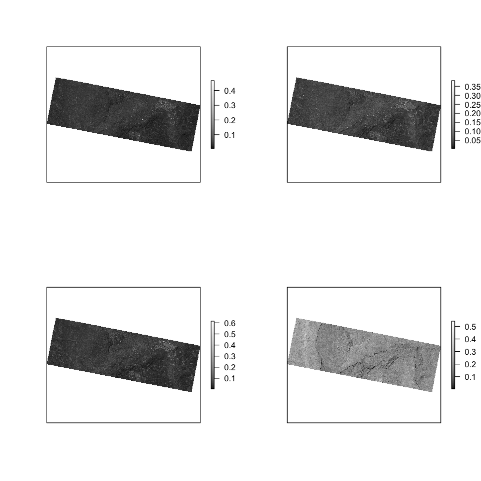

```r
par(mfrow=c(2,2))
options(repr.plot.width=8, repr.plot.height=8)

for(band in bands) {
  plot(ac_dos[[band]],
     col=grayscale_colors,
     axes=FALSE,
     main=cat(band, " Band DOS Reflectance", sep="")
    )
}
```

## Cálculo de Reflectancia DOS usando el método Apreciativo

```r
haze_toa <- estimateHaze(image, hazeBands = 1:nlayers(image), plot = FALSE)
names(haze_toa) <- bands
```

```r
haze_toa_r <- haze_toa

names(haze_toa_r) <- bands
for(band in bands) {
    haze_toa_r[[band]] = (haze_toa_r[[band]] * reflectance_coefficient[[band]])
}
Ldo_toa <- 0.01
Lpath_toa <- haze_toa_r - Ldo_toa

ac_toa_apr <- image
for(band in bands) {
  ac_toa_apr[[band]] =  ac_toa[[band]] - Lpath_toa[[band]]
}
ac_toa_apr
```

```
class       : RasterStack
dimensions  : 4352, 8985, 39102720, 4  (nrow, ncol, ncell, nlayers)
resolution  : 3, 3  (x, y)
extent      : 684891, 711846, 717039, 730095  (xmin, xmax, ymin, ymax)
coord. ref. : +proj=utm +zone=18 +datum=WGS84 +units=m +no_defs +ellps=WGS84 +towgs84=0,0,0
names       :          Blue,         Green,           Red,           NIR
min values  : -0.0245786390,  0.0003703603, -0.0229381046, -0.0031252198
max values  :     0.5741469,     0.4521361,     0.6620667,     0.9976342
```

## Cálculo de Reflectancia COS

Usando método tradicional

```r
ac_cos <- ac_toa / angle
ac_cos
```

```
class       : RasterBrick
dimensions  : 4352, 8985, 39102720, 4  (nrow, ncol, ncell, nlayers)
resolution  : 3, 3  (x, y)
extent      : 684891, 711846, 717039, 730095  (xmin, xmax, ymin, ymax)
coord. ref. : +proj=utm +zone=18 +datum=WGS84 +units=m +no_defs +ellps=WGS84 +towgs84=0,0,0
data source : in memory
names       :       Blue,      Green,        Red,        NIR
min values  : 0.05122112, 0.07482917, 0.01784203, 0.07947921
max values  :  0.8807564,  0.7007513,  0.9669174,  1.4660330
```

Usando método Apreciativo

```r
ac_cos_aprc <- ac_toa_apr / angle
ac_cos_aprc
```

[output not shown]

(c) Calcule la temperatura de superficie a partir de las bandas TIR

## Cálculo de temperatura de la superficie

Debido a que la imágen utilizada no cuenta con bandas termales se usa para este punto una imagen del sensor LANDSAT 8 con identificación `LC08_L1TP_008055_20150104_20170415_01_T1`. Para el cálculo se usa el algoritmo planteado por [(Avdan, U , & Jovanovska, G, 2016)](https://www.hindawi.com/journals/js/2016/1480307/#B15)[1]

```r
library(rLandsat8)
library(viridis)
setwd("/Users/oscar/Code/Maestria/perc_remota/data/images/landsat/")
product  <- "LC08_L1TP_008055_20150104_20170415_01_T1"
l <- ReadLandsat8(product)
```

Calculando Radiancia espectral para la imagen

```r
#Top of Atmospheric Spectral Radiance

LX <- calc( l$band$tirs1, fun=function(x){
  x * as.double(l$metadata$radiance_mult_band_10) + as.double(l$metadata$radiance_add_band_10)
  }
)
LX
```

```
class       : RasterLayer
dimensions  : 7731, 7571, 58531401  (nrow, ncol, ncell)
resolution  : 30, 30  (x, y)
extent      : 514185, 741315, 683085, 915015  (xmin, xmax, ymin, ymax)
coord. ref. : +proj=utm +zone=18 +datum=WGS84 +units=m +no_defs +ellps=WGS84 +towgs84=0,0,0
data source : in memory
names       : layer
values      : 5.879321, 11.47483  (min, max)
```

Convirtiendo Radiancia a temperatura del sensor

```r
#Conversion of Radiance to At-Sensor Temperature

BT <- calc( LX, fun=function(x){
  k2 <- as.numeric(l$metadata$k2_constant_band_10);
  k1 <- as.numeric(l$metadata$k1_constant_band_10);
  ( k2 / log( (k1/x) + 1) )  # converting to celcius
})
BT
```

```
class       : RasterLayer
dimensions  : 7731, 7571, 58531401  (nrow, ncol, ncell)
resolution  : 30, 30  (x, y)
extent      : 514185, 741315, 683085, 915015  (xmin, xmax, ymin, ymax)
coord. ref. : +proj=utm +zone=18 +datum=WGS84 +units=m +no_defs +ellps=WGS84 +towgs84=0,0,0
data source : in memory
names       : layer
values      : 270.2238, 312.5143  (min, max)
```

Calculando Índice NVDI. Primero es necesario calcular la reflectancia TOA para las Bandas RED y NIR

```r
#Calculating NDVI

#Toa reflectance
toa_reflectance <- l$band

toa_reflectance$red <- calc( l$band$red, fun=function(x){
  angle <- cos( (90 - as.numeric(l$metadata$sun_elevation)) * pi /180 );
  ml <- as.double(l$metadata$reflectance_mult_band_4);
  al <- as.double(l$metadata$reflectance_add_band_4);
  return (x * ml + al) / (angle)
})
toa_reflectance$red

toa_reflectance$nir <- calc( l$band$nir, fun=function(x){
  angle <- cos( (90 - as.numeric(l$metadata$sun_elevation)) * pi /180 );
  ml <- as.double(l$metadata$reflectance_mult_band_4);
  al <- as.double(l$metadata$reflectance_add_band_4);
  return (x * ml + al) / (angle);
})
toa_reflectance$nir

ndvi <- (toa_reflectance$nir - toa_reflectance$red) / (toa_reflectance$nir + toa_reflectance$red)
ndvi
```

```
class       : RasterLayer
dimensions  : 7731, 7571, 58531401  (nrow, ncol, ncell)
resolution  : 30, 30  (x, y)
extent      : 514185, 741315, 683085, 915015  (xmin, xmax, ymin, ymax)
coord. ref. : +proj=utm +zone=18 +datum=WGS84 +units=m +no_defs +ellps=WGS84 +towgs84=0,0,0
data source : in memory
names       : layer
values      : 0.0089, 1.01994  (min, max)
```

```
class       : RasterLayer
dimensions  : 7731, 7571, 58531401  (nrow, ncol, ncell)
resolution  : 30, 30  (x, y)
extent      : 514185, 741315, 683085, 915015  (xmin, xmax, ymin, ymax)
coord. ref. : +proj=utm +zone=18 +datum=WGS84 +units=m +no_defs +ellps=WGS84 +towgs84=0,0,0
data source : in memory
names       : layer
values      : -0.00462, 1.17042  (min, max)
```

```
class       : RasterLayer
dimensions  : 7731, 7571, 58531401  (nrow, ncol, ncell)
resolution  : 30, 30  (x, y)
extent      : 514185, 741315, 683085, 915015  (xmin, xmax, ymin, ymax)
coord. ref. : +proj=utm +zone=18 +datum=WGS84 +units=m +no_defs +ellps=WGS84 +towgs84=0,0,0
data source : in memory
names       : layer
values      : -1.358974, 0.8796774  (min, max)
```

Calculando la proporción de vegetación.El autor sugiere usar los valores de NDVI para vegetación y suelo 0.5 y 0.2 respectivamente.

```r
#Calculating the Proportion of Vegetation
ndvi_v = 0.5
ndvi_s = 0.2

p_v <- calc( ndvi, fun=function(ndvi_i){
  return (( (ndvi_i - ndvi_s) / (ndvi_v - ndvi_s) ) ^ 2)
})
p_v
```

```
class       : RasterLayer
dimensions  : 7731, 7571, 58531401  (nrow, ncol, ncell)
resolution  : 30, 30  (x, y)
extent      : 514185, 741315, 683085, 915015  (xmin, xmax, ymin, ymax)
coord. ref. : +proj=utm +zone=18 +datum=WGS84 +units=m +no_defs +ellps=WGS84 +towgs84=0,0,0
data source : in memory
names       : layer
values      : 0, 27.00446  (min, max)
```

Con base en la función condicional definida por el autor se calculan los valores de emisividad de superficie terrestre

```r
#Calculating Land Surface Emissivity

e_v = 0.973
e_s = 0.996
e_w = 0.991
C = 0.005



elambdafunc<- function(x) {
ndvi_i <- as.numeric(x);
pv <- (( (ndvi_i - ndvi_s) / (ndvi_v - ndvi_s) )^2);
ret <- ifelse(ndvi_i <= 0,
         e_w,
         ifelse(ndvi_i > 0 & ndvi_i < ndvi_s ,
           e_s,
         ifelse( ndvi_i >= ndvi_s & ndvi_i <= ndvi_v,
          (e_v * pv + e_s * (1 - pv) + C),
          ifelse(ndvi_i > ndvi_v,
          e_v,
          1
         )
       )));
  return( ret );
}
e_lambda <- calc( ndvi, fun=elambdafunc)
e_lambda
```

```
class       : RasterLayer
dimensions  : 7731, 7571, 58531401  (nrow, ncol, ncell)
resolution  : 30, 30  (x, y)
extent      : 514185, 741315, 683085, 915015  (xmin, xmax, ymin, ymax)
coord. ref. : +proj=utm +zone=18 +datum=WGS84 +units=m +no_defs +ellps=WGS84 +towgs84=0,0,0
data source : in memory
names       : layer
values      : 0.973, 1.001  (min, max)
```

Se calcula la temperatura de la superficie terrestre.

```
class       : RasterLayer
dimensions  : 7731, 7571, 58531401  (nrow, ncol, ncell)
resolution  : 30, 30  (x, y)
extent      : 514185, 741315, 683085, 915015  (xmin, xmax, ymin, ymax)
coord. ref. : +proj=utm +zone=18 +datum=WGS84 +units=m +no_defs +ellps=WGS84 +towgs84=0,0,0
data source : in memory
names       : layer
values      : -2.37091, 39.31379  (min, max)
```

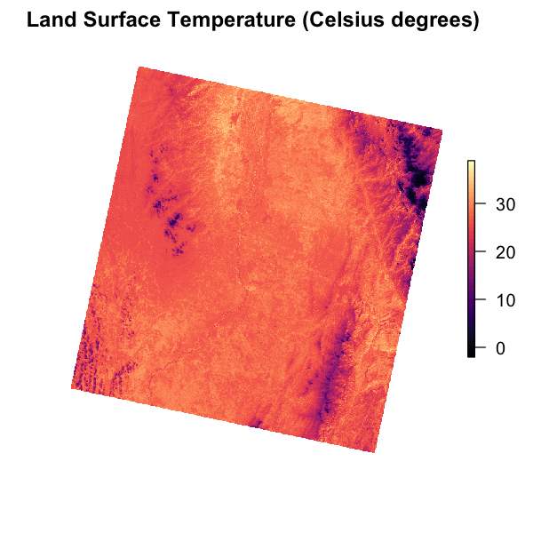

```r
#Calculating LST
boltzmann <- 1.38e-23
planck <- 6.626e-34
lambda <- 1.0895e-5
velocity_of_light <- 2.998e8

p <- planck * (velocity_of_light/boltzmann)

Ts <- BT / (1 + ( (lambda * BT/p) * log(e_lambda) ) )
Ts <- Ts -  273.15
Ts
options(repr.plot.width=5, repr.plot.height=5)
colors <- viridis(50,option = "A")
plot(Ts,main = "Land Surface Temperature (Celsius degrees)",  axes = FALSE, box = FALSE, col=colors)
```

c) Calcule tres índices espectrales que sean relevantes en su estudio

## Índice espectral NDVI

```
class       : RasterLayer
dimensions  : 4352, 8985, 39102720  (nrow, ncol, ncell)
resolution  : 3, 3  (x, y)
extent      : 684891, 711846, 717039, 730095  (xmin, xmax, ymin, ymax)
coord. ref. : +proj=utm +zone=18 +datum=WGS84 +units=m +no_defs +ellps=WGS84 +towgs84=0,0,0
data source : in memory
names       : layer
values      : -1.450903, 1.21033  (min, max)
```

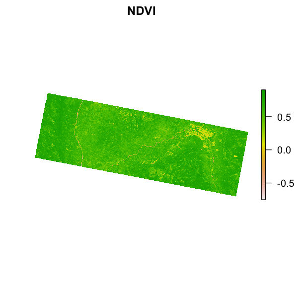

```r
i_nvdi <- (ac_dos[["NIR"]] - ac_dos[["Red"]])  / (ac_dos[["NIR"]] + ac_dos[["Red"]])
i_nvdi
options(repr.plot.width=5, repr.plot.height=5)

plot(i_nvdi,main = "NDVI",  axes = FALSE, box = FALSE)
```

Para el cálculo de otros índices espectrales se toma la imágen LANDSAT 8 usada en el anterior proceso de cálculo de temperaturas.

## Índice espectral LSWI

```
class       : RasterLayer
dimensions  : 7731, 7571, 58531401  (nrow, ncol, ncell)
resolution  : 30, 30  (x, y)
extent      : 514185, 741315, 683085, 915015  (xmin, xmax, ymin, ymax)
coord. ref. : +proj=utm +zone=18 +datum=WGS84 +units=m +no_defs +ellps=WGS84 +towgs84=0,0,0
data source : in memory
names       : layer
values      : -0.6666031, 0.5515365  (min, max)
```

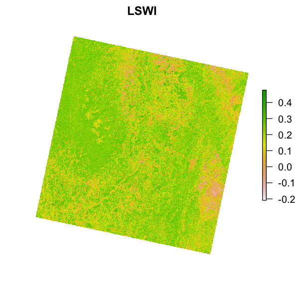

```r
lswi <- (l$band$nir- l$band$swir1) / (l$band$nir+ l$band$swir1)
lswi
plot(lswi,main = "LSWI",  axes = FALSE, box = FALSE)
```

## Índice espectral MNDWI

```
class       : RasterLayer
dimensions  : 7731, 7571, 58531401  (nrow, ncol, ncell)
resolution  : 30, 30  (x, y)
extent      : 514185, 741315, 683085, 915015  (xmin, xmax, ymin, ymax)
coord. ref. : +proj=utm +zone=18 +datum=WGS84 +units=m +no_defs +ellps=WGS84 +towgs84=0,0,0
data source : in memory
names       : layer
values      : -0.7378632, 0.4395706  (min, max)
```

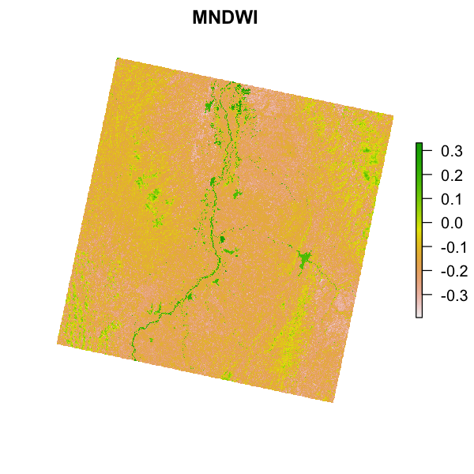

```r
mndwi <- (l$band$green- l$band$swir1) / (l$band$green+ l$band$swir1)
mndwi
plot(mndwi,main = "MNDWI",  axes = FALSE, box = FALSE)
```

# Referencias

1. Avdan, U., & Jovanovska, G. (2016). Algorithm for automated mapping of land surface temperature using LANDSAT 8 satellite data. Journal of Sensors, 2016, 1–8. https://doi.org/10.1155/2016/1480307